# How to identify specimen records with suspicious coordinate data, using R and iDigBio

Code here written by [Erica Krimmel](https://orcid.org/0000-0003-3192-0080). Please see **Use Case: [Identify specimen records with suspicious coordinate data](https://biodiversity-specimen-data.github.io/specimen-data-use-case/use-case/identify-suspicious-coordinate-data)** for context. Code here is modified from [original](https://github.com/ekrimmel/idigbio-api-dq-geo) given in a presentation at the 2019 ADBC Summit in Gainesville, FL.

```r
# Load core libraries; install these packages if you have not already
library(ridigbio)
library(tidyverse)

# Load library for making nice HTML output
library(kableExtra)

# Load libraries for visualizing geographic data
library(leaflet)
```

In this use case for the [iDigBio API](https://github.com/iDigBio/idigbio-search-api/wiki) we explore a situation where **geographic coordinate data** from the provider was modified by iDigBio during its data quality assurance process. See [here](https://github.com/iDigBio/idigbio-search-api/wiki/Data-Quality-Flags) for more information about iDigBio’s data quality flags.

## Write a query to search for specimen records

First, let’s find all the specimen records for the data quality flag we are interested in. Do this using the `idig_search_records` function from the `ridigbio` package. You can learn more about this function from the [iDigBio API documentation](https://github.com/iDigBio/idigbio-search-api/wiki) and [ridigbio documentation](https://cran.r-project.org/web/packages/ridigbio/ridigbio.pdf). In this example, we want to start by searching for specimens flagged with “rev_geocode_corrected.”

```r
# Edit the fields (e.g. `flags`) and values (e.g. "rev_geocode_corrected") in
# `list()` to adjust your query and the fields (e.g. `uuid`) in `fields` to
# adjust the columns returned in your results
df_flagCoord <- idig_search_records(rq = list(flags = "rev_geocode_corrected",
                                              institutioncode = "lacm"),
                    fields = c("uuid",
                               "institutioncode",
                               "collectioncode",
                               "country",
                               "data.dwc:country",
                               "stateprovince",
                               "county",
                               "locality",
                               "geopoint",
                               "data.dwc:decimalLongitude",
                               "data.dwc:decimalLatitude",
                               "flags"),
                    limit = 100000) %>%
  # Rename fields to more easily reflect their provenance (either from the
  # data provider directly or modified by the data aggregator)
  rename(provider_lon = `data.dwc:decimalLongitude`,
         provider_lat = `data.dwc:decimalLatitude`,
         provider_country = `data.dwc:country`,
         aggregator_lon = `geopoint.lon`,
         aggregator_lat = `geopoint.lat`,
         aggregator_country = country,
         aggregator_stateprovince = stateprovince,
         aggregator_county = county,
         aggregator_locality = locality) %>%
  # Reorder columns for easier viewing
  select(uuid, institutioncode, collectioncode, provider_lat, aggregator_lat,
         provider_lon, aggregator_lon, provider_country, aggregator_country,
         aggregator_stateprovince, aggregator_county, aggregator_locality,
         flags)
```

Here is what our query result data looks like:

| uuid | institutioncode | collectioncode | provider_lat | aggregator_lat | provider_lon | aggregator_lon | provider_country | aggregator_country | aggregator_stateprovince | aggregator_county | aggregator_locality |
| --- | --- | --- | --- | --- | --- | --- | --- | --- | --- | --- | --- |
| 004f15e3-92e8-4c8d-8a9b-3074a37a27dc | lacm | fish | -39.2333333 | -75.71667 | -75.7166667 | 39.23333 | Antarctica | antarctica | NA | NA | NA |
| 004fa3d0-7d99-4af4-98b8-dd6c64e68906 | lacm | fish | -62.5 | -62.50000 | -108.5833333 | 108.58333 | Antarctica | antarctica | NA | NA | NA |
| 00a0ea39-6602-4096-ab4e-a8e5dce43760 | lacm | fish | -59.2333333 | -69.21667 | -69.2166667 | 59.23333 | Antarctica | antarctica | NA | NA | NA |
| 00ae30fc-e9fb-4786-9f3c-ce6270371d7a | lacm | fish | -36.0166667 | -83.00000 | -83 | -36.01667 | Antarctica | antarctica | NA | NA | NA |
| 00b60cb3-2390-4125-b679-711e6cc06298 | lacm | fish | -55.3666667 | -78.13333 | -78.1333333 | 55.36667 | Antarctica | antarctica | NA | NA | NA |
| 00b92804-7166-48f2-81c5-583741d90400 | lacm | fish | -56.1 | -79.06667 | -79.0666667 | 56.10000 | Antarctica | antarctica | NA | NA | NA |
| 00bd0dab-5c51-475e-b93c-f0c52f703b5f | lacm | fish | -57.0666667 | -59.55000 | -59.55 | -57.06667 | Antarctica | antarctica | NA | NA | NA |
| 00dd683d-e6ac-4031-a388-f0b8de0506e0 | lacm | fish | -68.85 | -68.85000 | -114.1333333 | 114.13333 | Antarctica | antarctica | NA | NA | NA |
| 00e7660e-6f68-4966-a2d8-ad076261adc7 | lacm | fish | -39.2333333 | -75.71667 | -75.7166667 | 39.23333 | Antarctica | antarctica | NA | NA | NA |
| 00ece399-7933-4ffa-b6f4-319d41ea25dc | lacm | fish | -56.0666667 | -82.83333 | -82.8333333 | -56.06667 | Antarctica | antarctica | NA | NA | NA |
| 00fa11b3-9ba1-45ad-8cc9-b2b0586f7492 | lacm | fish | -51.5 | -77.58333 | -77.5833333 | 51.50000 | Antarctica | antarctica | NA | NA | NA |
| 0105c782-ad92-49fa-b88e-254c14767072 | lacm | fish | -62.2166667 | -62.21667 | -95.65 | 95.65000 | Antarctica | antarctica | NA | NA | NA |
| 010b1128-4d78-4545-b73d-9815ce39e215 | lacm | fish | -59.6333333 | -82.45000 | -82.45 | -59.63333 | Antarctica | antarctica | NA | NA | NA |
| 0120df13-f6a4-4854-8d9f-a59998ecc537 | lacm | fish | -60.1166667 | -70.13333 | -70.1333333 | 60.11667 | Antarctica | antarctica | NA | NA | NA |
| 01381f5e-6b15-44a8-a2f3-5761100b630c | lacm | herps | 26.753 | 26.75300 | 80.949 | -80.94900 | United States | united states | florida | hendry | best western hotel, clewiston |
| 0138fc7e-1a82-4526-8881-6bc74ba6749f | lacm | fish | -63.45 | -86.83333 | -86.8333333 | -63.45000 | Antarctica | antarctica | NA | NA | NA |
| 0143216a-d45d-4f44-8957-c8d9985e92e6 | lacm | fish | -56.15 | -60.90000 | -60.9 | -56.15000 | Antarctica | antarctica | NA | NA | NA |
| 01626bec-6af3-4b46-a184-971d002e5822 | lacm | fish | -57.2333333 | -62.76667 | -62.7666667 | -57.23333 | Antarctica | antarctica | NA | NA | NA |
| 01b3127e-5815-43c9-a5fc-d064bf21eb89 | lacm | fish | -59.6166667 | -88.90000 | -88.9 | -59.61667 | Antarctica | antarctica | NA | NA | NA |
| 01ce0ad8-a0b4-4dfd-93f6-3eb597070f90 | lacm | fish | -53.3 | -75.53333 | -75.5333333 | 53.30000 | Antarctica | antarctica | NA | NA | NA |
| 01e47af0-1c6d-49b3-b6df-86e7aeb5e8d6 | lacm | fish | -40.0166667 | -82.81667 | -82.8166667 | -40.01667 | Antarctica | antarctica | NA | NA | NA |
| 01fc820f-2b74-4e28-8470-db1bfcd37c2e | lacm | fish | -57.3333333 | -74.70000 | -74.7 | 57.33333 | Antarctica | antarctica | NA | NA | NA |
| 02249913-685c-422f-b73a-ac1d439ad607 | lacm | fish | -44.6833333 | -76.06667 | -76.0666667 | 44.68333 | Antarctica | antarctica | NA | NA | NA |
| 023cac7a-2468-42ab-a586-bcb0f856d31f | lacm | fish | -65.0833333 | -65.08333 | -41.3 | 41.30000 | Antarctica | antarctica | NA | NA | NA |
| 0283d543-06c5-4674-a42c-ca375db31892 | lacm | fish | -42 | -86.00000 | -86 | -42.00000 | Antarctica | antarctica | NA | NA | NA |
| 02984cf6-e6e8-408b-889d-e073ab15accf | lacm | fish | -59.9333333 | -69.00000 | -69 | 59.93333 | Antarctica | antarctica | NA | NA | NA |
| 029ac4ca-8f8c-4f1e-a33a-da7e517ef402 | lacm | fish | -39.3916667 | -73.55000 | -73.55 | 39.39167 | Antarctica | antarctica | NA | NA | NA |
| 02a0aa6f-fcdd-48c5-a45c-0a255b141d82 | lacm | fish | -47.4333333 | -76.66667 | -76.6666667 | 47.43333 | Antarctica | antarctica | NA | NA | NA |
| 02a5f38f-cd94-4b9c-af7d-260922884712 | lacm | herps | -26.8 | -20.88333 | 20.8833333 | 26.80000 | Botswana | botswana | NA | NA | 7 mi n, 12 mi e jct., molopo-nossob rivers |
| 02b1a6b5-0b26-4f26-b2a2-3f0e4d7e3cf6 | lacm | fish | -45.0166667 | -76.55000 | -76.55 | 45.01667 | Antarctica | antarctica | NA | NA | NA |
| 02b64cdc-54f3-442b-90d2-a2cf98bdc13a | lacm | fish | -53.55 | -70.75000 | -70.75 | 53.55000 | Antarctica | antarctica | NA | NA | NA |
| 02b80fb9-09aa-4d95-8e7d-6894327b7dec | lacm | fish | -41.9833333 | -86.11667 | -86.1166667 | -41.98333 | Antarctica | antarctica | NA | NA | NA |
| 02c9ee2d-561e-44de-85af-5a46a67f8cad | lacm | fish | -57.8666667 | -74.71667 | -74.7166667 | 57.86667 | Antarctica | antarctica | NA | NA | NA |
| 0309ac59-7460-4d3f-85e3-a3331f2b7443 | lacm | fish | -67.9166667 | -67.91667 | -103.2166667 | 103.21667 | Antarctica | antarctica | NA | NA | NA |
| 03349313-c8f0-4d21-b27a-fc566f86a557 | lacm | fish | -44.6833333 | -76.06667 | -76.0666667 | 44.68333 | Antarctica | antarctica | NA | NA | NA |
| 035b5037-fd54-493d-bc8d-cfffb5e69e80 | lacm | fish | -38.15 | -74.51667 | -74.5166667 | 38.15000 | Antarctica | antarctica | NA | NA | NA |
| 03965834-16f2-45f1-bf63-8d5975e9c218 | lacm | herps | -26.8 | -20.88333 | 20.8833333 | 26.80000 | Botswana | botswana | NA | NA | 7 mi n, 12 mi e jct., molopo-nossob rivers |
| 03b8814f-208b-411a-a72f-6edbc745e781 | lacm | fish | -57.2333333 | -70.95000 | -70.95 | 57.23333 | Antarctica | antarctica | NA | NA | NA |
| 03bb1ab1-5226-4a07-a8df-d826c911be45 | lacm | fish | -62.7 | -78.56667 | -78.5666667 | 62.70000 | Antarctica | antarctica | NA | NA | NA |
| 03bbad49-568d-4625-836b-7ca587be33af | lacm | fish | -33.55 | -72.75000 | -72.75 | 33.55000 | Antarctica | antarctica | NA | NA | NA |
| 03bc3bbe-af95-4adb-b9fa-9ed28dd70a94 | lacm | fish | -54.895 | -65.45667 | -65.4566667 | -54.89500 | Antarctica | antarctica | NA | NA | NA |
| 03dd5da9-ceb3-4481-b722-3913479b8b54 | lacm | fish | -41.0833333 | -74.90000 | -74.9 | 41.08333 | Antarctica | antarctica | NA | NA | NA |
| 03e5220a-9afe-4a8a-8858-4b47505fb6d3 | lacm | fish | -36.0166667 | -83.00000 | -83 | -36.01667 | Antarctica | antarctica | NA | NA | NA |
| 03e6c3f1-6343-4330-93c2-00511202dad5 | lacm | birds | -65.18 | -65.18000 | -43.72 | 43.72000 | Antarctica | antarctica | NA | NA | NA |
| 03ec203f-38aa-41a8-8c16-fc8be1d56ffb | lacm | fish | -59.8666667 | -82.83333 | -82.8333333 | -59.86667 | Antarctica | antarctica | NA | NA | NA |
| 04186251-8b4f-4973-a397-5f0c45e837f3 | lacm | fish | -36.3166667 | -83.00000 | -83 | -36.31667 | Antarctica | antarctica | NA | NA | NA |
| 04221f29-d45d-487e-8b24-b55975aa093e | lacm | fish | -51.5 | -77.58333 | -77.5833333 | 51.50000 | Antarctica | antarctica | NA | NA | NA |
| 04379435-5305-49a8-a308-fa4d252a8d94 | lacm | fish | -59.85 | -78.88333 | -78.8833333 | 59.85000 | Antarctica | antarctica | NA | NA | NA |
| 04730a4e-792f-452d-8f5a-e724f2876562 | lacm | fish | -59.1166667 | -66.96667 | -66.9666667 | -59.11667 | Antarctica | antarctica | NA | NA | NA |
| 04920726-4880-4495-9163-b7ec5475fb4b | lacm | fish | -53.1833333 | -70.83333 | -70.8333333 | 53.18333 | Antarctica | antarctica | NA | NA | NA |

## Visualize suspicious coordinates

One example of a geographic coordinate data quality issue would be that the latitude/longitude has a reversed sign, e.g. the data provider gave the value *latitude* = “7.1789” but meant *latitude* = “-7.1789.” In the map below we can see a few examples of specimen records published to iDigBio where this is the case. These data have been adjusted by iDigBio and this action is recorded with the data quality flag “rev_geocode_flip_lat_sign.”

```r
# Create function to allow subsetting the `df_flagCoord` dataset by other flags
# found on these same records
df_flagSubset <- function(subsetFlag) {
  df_flagCoord %>%
  filter(grepl(subsetFlag, flags)) %>%
  select(uuid, matches("_lat|_lon")) %>%
  unite(provider_coords, c("provider_lat", "provider_lon"), sep = ",") %>%
  unite(aggregator_coords, c("aggregator_lat", "aggregator_lon"), sep = ",") %>%
  gather(key = type, value = coordinates, -uuid) %>%
  separate(coordinates, c("lat","lon"), sep = ",") %>%
  mutate(lat = as.numeric(lat)) %>%
  mutate(lon = as.numeric(lon)) %>%
  arrange(uuid, type)}

# Subset `df_flagCoord` by records flagged for having had their latitude negated
# to place point in stated country by reverse geocoding process
df_rev_geocode_lat_sign <- df_flagSubset("rev_geocode_lat_sign")

# Create map displaying a few examples of records with the
# rev_geocode_flip_lat_sign flag
pal <- colorFactor(palette = c("#d7191c", "#fdae61", "#ffffbf", "#abdda4", "#2b83ba"),
                   domain = df_rev_geocode_lat_sign$uuid[1:10])

map <- df_rev_geocode_lat_sign[1:10,] %>%
  mutate(popup = str_c(type, " = ", lat, ", ", lon, sep = "")) %>%
  leaflet() %>%
  addTiles() %>%
  addCircleMarkers(
    lng = ~lon,
    lat = ~lat,
    radius = 10,
    weight = 1,
    color = ~pal(uuid),
    stroke = FALSE,
    fillOpacity = 100,
    popup = ~popup) %>%
  addLegend("bottomright", pal = pal, values = ~uuid,
    title = "Specimen Records",
    opacity = 1)
```

[interactive chart not shown]

```r
# Create map displaying example of record possibly assigned the
# rev_geocode_flip_lat_sign flag incorrectly
df_flagCoord %>%
  filter(uuid == "004fa3d0-7d99-4af4-98b8-dd6c64e68906") %>%
  select(uuid, matches("_lat|_lon")) %>%
  unite(provider_coords, c("provider_lat", "provider_lon"), sep = ",") %>%
  unite(aggregator_coords, c("aggregator_lat", "aggregator_lon"), sep = ",") %>%
  gather(key = type, value = coordinates, -uuid) %>%
  separate(coordinates, c("lat","lon"), sep = ",") %>%
  mutate(lat = as.numeric(lat)) %>%
  mutate(lon = as.numeric(lon)) %>%
  arrange(uuid, type) %>%
  mutate(popup = str_c(type, " = ", lat, ", ", lon, sep = "")) %>%
  leaflet() %>%
  addTiles() %>%
  addCircleMarkers(
    lng = ~lon,
    lat = ~lat,
    radius = 10,
    weight = 1,
    color = ~pal(uuid),
    stroke = FALSE,
    fillOpacity = 100,
    popup = ~popup) %>%
  addLegend("bottomright", pal = pal, values = ~uuid,
    title = "Specimen Record",
    opacity = 1)
```

[interactive chart not shown]

## Summarize and explore data

The iDigBio API provides a means for an institution to examine data quality issues across collections, which sometimes is not possible internally when data in different collections are managed in different databases.

```r
# Summarize flagged records by collection type
spmByColl <- df_flagCoord %>%
  group_by(collectioncode) %>%
  tally()

# Generate graph to display counts of flagged records by collection within the
# institution
graph_spmByColl <- ggplot(spmByColl,
                          aes(x = reorder(collectioncode, -n),
                              y = n,
                              fill = collectioncode)) +
  geom_col() +
  theme(panel.background = element_blank(),
        legend.title = element_blank(),
        axis.title.x = element_text(face = "bold"),
        axis.text.y = element_blank(),
        axis.ticks.y = element_blank(),
        axis.title.y = element_text(face = "bold"),
        plot.title = element_text(size = 12, face = "bold")) +
  labs(x = "collection",
       y = "# of specimen records",
       title = "LACM records flagged with geo-coordinate data quality issues by iDigBio") +
  geom_text(aes(label = n, vjust = -0.5))

# Get count of total records published by the institution using function
# `idig_count_records`
totalInstSpm <- idig_count_records(rq = list(institutioncode = "lacm"))

# Calculate flagged records as percent of total records
percentFlagged <- sum(spmByColl$n)/totalInstSpm*100
```

For example, we can ask how many specimen records from which collections at the Natural History Museum of Los Angeles (LACM) have been flagged as “rev_geocode_corrected” by iDigBio. *As an aside, although this graph highlights the number of specimen records with data quality issues, these represent only 0.36% of the total specimen records published by LACM.*

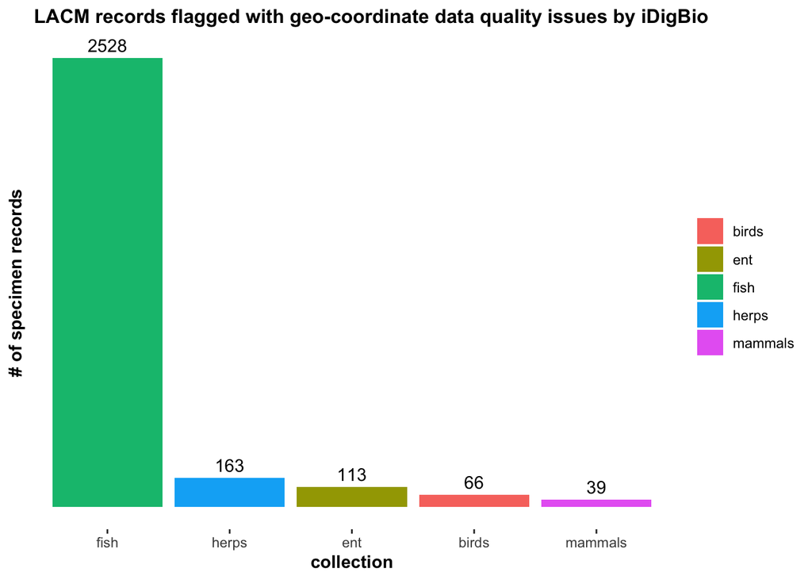

We can also explore what *other* data quality flags these specimen records have been flagged with.

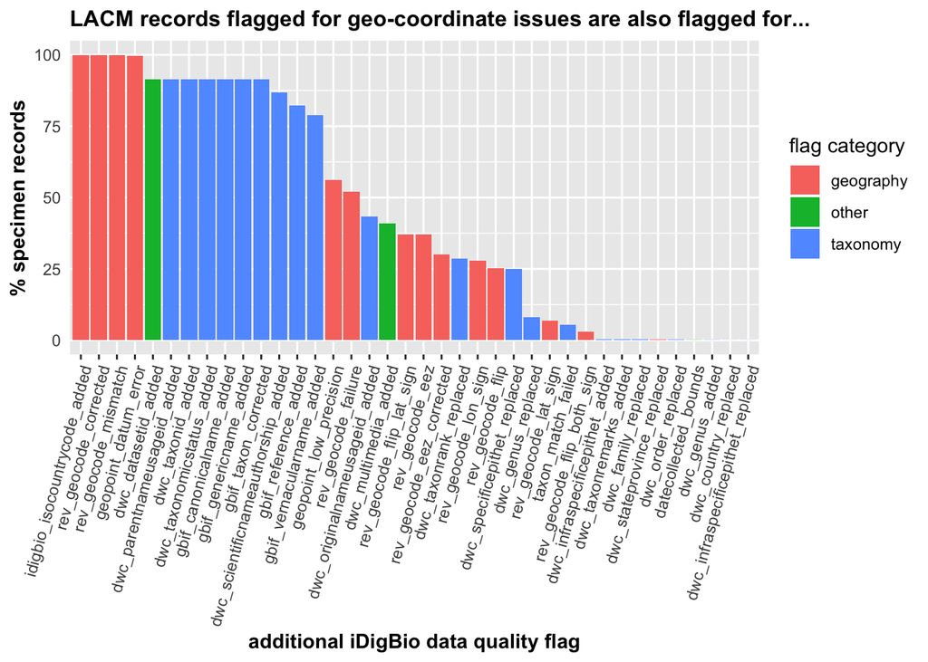

```r
# Collate `df_flagAssoc` to describe other data quality flags that are associated
# with rev_geocode_corrected in `df_flagCoord`
df_flagAssoc <- df_flagCoord %>%
  select(uuid, flags) %>%
  unnest(flags) %>%
  group_by(flags) %>%
  tally() %>%
  mutate("category" = case_when(str_detect(flags, "geo|country|state")
                              ~ "geography",
                      str_detect(flags, "dwc_datasetid_added|dwc_multimedia_added|datecollected_bounds")
                              ~ "other",
                      str_detect(flags, "gbif|dwc|tax")
                              ~ "taxonomy")) %>%
  mutate("percent" = n/(nrow(df_flagCoord))*100) %>%
  arrange(category, desc(n))

# Visualize associated data quality flags
ggplot(df_flagAssoc, aes(x = reorder(flags, -percent), y = percent, fill = category)) +
  geom_col() +
  theme(axis.title.x = element_text(face = "bold"),
        axis.text.x = element_text(angle = 75, hjust = 1),
        axis.ticks.y = element_blank(),
        axis.title.y = element_text(face = "bold"),
        plot.title = element_text(size = 12, face = "bold")
        ) +
  labs(x = "additional iDigBio data quality flag",
       y = "% specimen records",
       title = "LACM records flagged for geo-coordinate issues are also flagged for...",
       fill = "flag category")
```